# Proposal Analysis

/////////////////////////////////////////////////////////////////////////////////////////////////////////////////// Description: This notebook file was created by A. Trelles on 12/28/19 as part of the Strategy Paper. ///////////////////////////////////////////////////////////////////////////////////////////////////////////////////

#General Description: This analysis is used as a reference to write the code for the analysis of partisan counterporposals for the 2013 and 2017 redistricting process in relation with partisan ruling status, its strenght (vote returns), and state level coalition dynamics.

The first part of the ProposalAnalysis.Rmd IS NOT CODE. It describes the general objectives of the analysis based on the hypotheses derived from the paper and the available data we have to test them. In all cases, the DV is related to a party´s decision to formulate a counterporposal.

General Hypotheses H1, H2, and H3 assume the DV is if a party formulated a counterporposal, and vary according the ruling party (H1), party strenght/vote returns (H2), and coalitions (H3).

// Setup //

#Libraries

```r
require(tidyverse)
require(magrittr)
require(tidylog)
require(fastDummies)
require(tidymodels)
require(gt)
require(car)
require(lmtest)
require(ordinal)
require(rcompanion)
require(caret)
require(readxl)
```

#bring in Data

Generate data frame for testing entry decisions.

Data frame: ys.proposed

Main unit of analysis: (party BY state AND year) – summarize the actions each party took for each state in year – NOT individual proposals

Measures (aggregated by STATE and YEAR )

- numproposals - number of proposals made by party
- didPropose - logical - whether party made any propoals -dummy variable derived from number of proposals > 0
- didControl - logical - whether party was in sole control of the state for the entire relevant period , derived from (control)
- didRule - logical whether party was in power at the end of the period, while redistricting takes place
- didWinever - party was in control at least once during the period

State-level measures inherited from controlByWindow() - partylist, partyseq, partytab, singlecontrol, percentsingle, primary, secondary, tertiary State-level measures added: - singlecontrol - dummy, where singlecontrol != NONE NOTE: these are measures of the STATE at that time, not specific to party - partylist - names of parties in control of state over the relevant prior period, names may repeat if party control cycles back and forth - year_2017 - indicator if year is 2017, based on (year) - ruleparty - name of party that was in control at last year of period

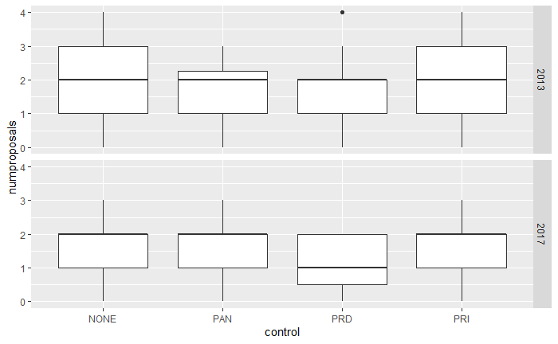

```r
#Code generating needed variables
ys.proposed <- propfull.df %>% group_by(actor,edon,year) %>% summarise(numproposals=sum(PROPOSED,na.rm=TRUE))
#output <- propstrue(proposals.df)
ys.control <- grule.df %>%  controlByWindow(2000,2013)%>%  mutate (edon=edon, year=2013,control=if_else(singlecontrol,primary,"NONE"))
ys.control %<>% bind_rows (grule.df %>%  controlByWindow(2000,2017) %>% mutate(edon=edon, year=2017,control=if_else(singlecontrol,primary,"NONE")))
ys.proposed %<>% left_join(ys.control)
rm(ys.control)
ys.proposed %<>% rowwise() %>% mutate(didPropose=(numproposals>0),didControl=(actor==control))
ys.proposed %<>% rowwise() %>% mutate(year_2017 = ifelse(year == 2017, 1, 0))
ys.proposed %<>% rowwise() %>% mutate(ruleparty = tail(partylist,1))
ys.proposed %<>% rowwise() %>% mutate(didRule=(actor==ruleparty))
ys.proposed %<>% rowwise() %>% mutate(didWinever=(actor %in% partylist))

ys.proposed %>% ggplot(aes(control,numproposals))+geom_boxplot()+facet_grid(rows=vars(year))
```

```r
# join with parties
ys.proposed %<>% left_join(actors.df)
```

Strategic Position Categorization

A party in a “strong” position political position in the state, then they are more likely to propose than a party with a less “strong” position.

The variables used in the decision tree embody levels of competition in each state. A state controlled by a single party during the period has low levels of political competition, for example. A state with a party which has not won a majority of elections but has won at least once has some degree of power in a competitive state (there are at least two parties competing), as another example. The former has a better “strategic position” than the latter.

The “Strategic Positions” are defined as follows: 1. Party a) Controls during redistricting year b) has controlled state in all previous observed periods

2. Party a) Controls during redistricting year b) has NOT controlled state in all previously observed periods
3. Party a) DOES NOT control during the redistricting year b) has NOT controlled state in all previously observed periods c) has won a MAJORITY of previous elections in observed time period
4. Party a) DOES NOT control during the redistricting year b) has NOT controlled state in all previously observed periods c) has won a MINORITY of previous elections in observed time period
5. Party a) DOES NOT control during the redistricting year b) has NOT controlled state in all previously observed periods c) has won NONE of the previous elections during the time period
6. Party a) DOES NOT control during the redistricting year b) has NOT controlled state in all previously observed periods c) has won NONE of the previous elections during the time period d) another party has won ALL previous elections

[output not shown]

```r
#CLM model first
clm.mod <- ys.proposed %>% clm(as.ordered(didPropose)~as.ordered(PartyStratPos), data=., HESS=TRUE)
```

```
(1) Hessian is numerically singular: parameters are not uniquely determined
In addition: Absolute convergence criterion was met, but relative criterion was not met
```

```r
summary(clm.mod)
```

```
formula: as.ordered(didPropose) ~ as.ordered(PartyStratPos)
data:    .
```

| link | threshold | nobs | logLik | AIC | niter | max.grad | cond.H |
| --- | --- | --- | --- | --- | --- | --- | --- |
| logit | flexible | 523 | -134.96 | 281.91 | 21(0) | 5.78e-09 | 1.6e+10 |

```
Coefficients:
                            Estimate Std. Error z value Pr(>|z|)
as.ordered(PartyStratPos).L  -19.827         NA      NA       NA
as.ordered(PartyStratPos).Q    9.229         NA      NA       NA
as.ordered(PartyStratPos).C    2.962         NA      NA       NA
as.ordered(PartyStratPos)^4   -7.881         NA      NA       NA
as.ordered(PartyStratPos)^5    5.753         NA      NA       NA

Threshold coefficients:
           Estimate Std. Error z value
FALSE|TRUE   -9.275         NA      NA
```

```r
#confint(clm.mod)
exp(coef(clm.mod)[2])
```

```
as.ordered(PartyStratPos).L
               2.449531e-09
```

```r
exp(coef(clm.mod)[3])
```

```
as.ordered(PartyStratPos).Q
                   10188.94
```

```r
exp(coef(clm.mod)[4])
```

```
as.ordered(PartyStratPos).C
                   19.34439
```

```r
exp(coef(clm.mod)[5])
```

```
as.ordered(PartyStratPos)^4
               0.0003778793
```

```r
exp(coef(clm.mod)[6])
```

```
as.ordered(PartyStratPos)^5
                   315.1151
```

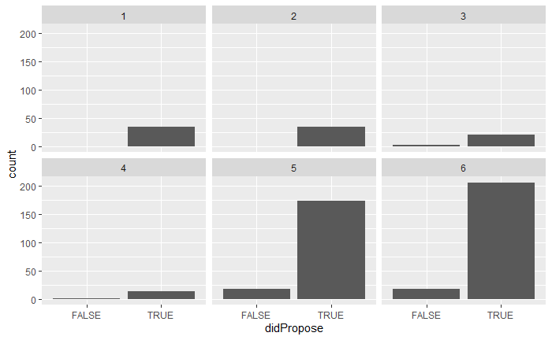

```r
ys.proposed %>% ggplot(aes(didPropose)) + geom_bar() +facet_wrap(~PartyStratPos)
```

```r
clm.pred <- predict(clm.mod)
summary(clm.pred)
```

```
    Length Class  Mode
fit 523    -none- numeric
```

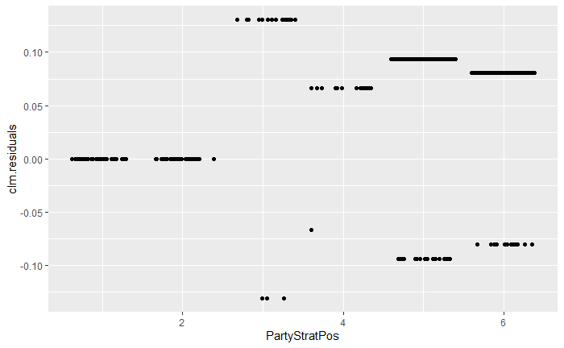

```r
x <- ys.proposed$didPropose - clm.mod$fitted.values
ys.proposed %<>% cbind(x)
ys.proposed <- ys.proposed %>% rename(clm.residuals = x)
ys.proposed %>% ggplot(aes(PartyStratPos, clm.residuals)) + geom_jitter()
```

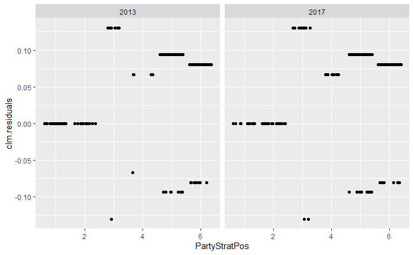

```r
ys.proposed %>% ggplot(aes(PartyStratPos, clm.residuals)) + geom_jitter() + facet_wrap(~year)
```

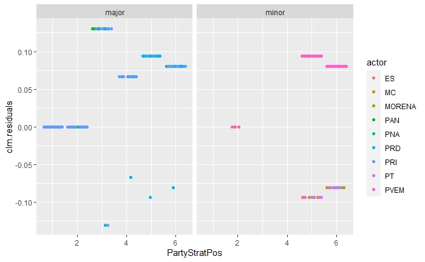

```r
ys.proposed %>% filter(actortype == "major" | actortype == "minor") %>% ggplot(aes(PartyStratPos, clm.residuals, color=actor)) + geom_jitter() + facet_wrap(~actortype)
```

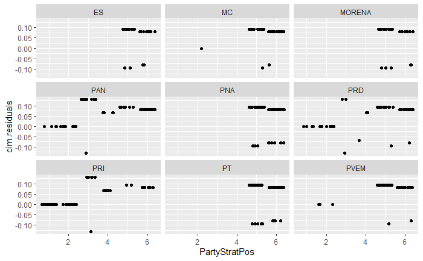

```r
ys.proposed %>% filter(actortype == "major" | actortype == "minor") %>% ggplot(aes(PartyStratPos, clm.residuals)) + geom_jitter() + facet_wrap(~actor)
```

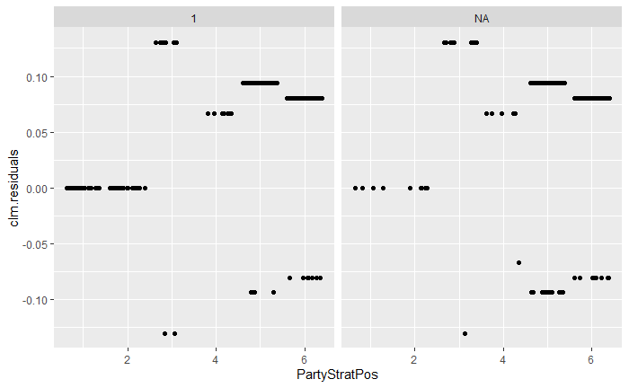

```r
ys.proposed %>% ggplot(aes(PartyStratPos, clm.residuals)) + geom_jitter() + facet_wrap(~inCoalition)
```

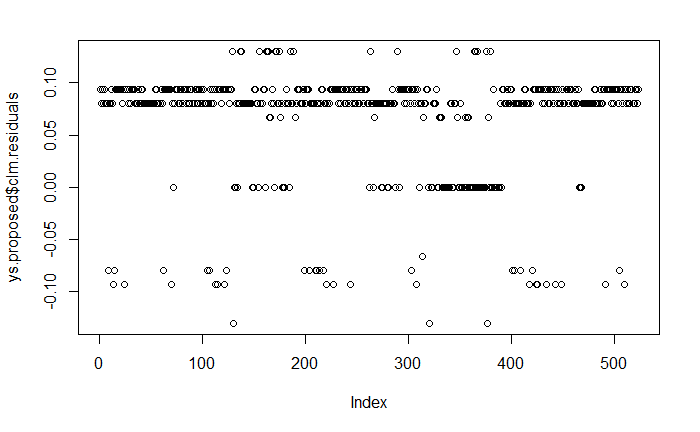

```r
#maybe parties in color in the graphs?
#minor party in a coalition or not?

plot(ys.proposed$clm.residuals)
```

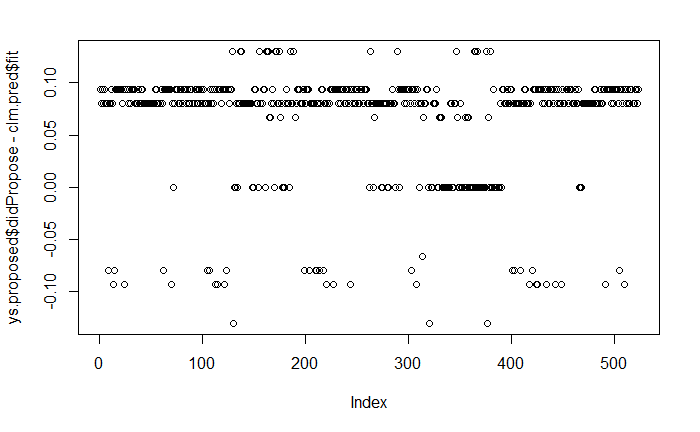

```r
plot(ys.proposed$didPropose - clm.pred$fit)
```

```r
#Generating confusion matrix for CLM model
ys.proposed %<>% mutate(clm50 = ifelse(clm.pred$fit >= 0.5, 1, 0))
ys.proposed %<>% mutate(clm90 = ifelse(clm.pred$fit >= 0.9, 1, 0))

confusionMatrix(as.factor(ys.proposed$clm50), as.factor(ys.proposed$didPropose.num))
```

```
Confusion Matrix and Statistics

          Reference
Prediction   0   1
         0  40   0
         1   0 483

               Accuracy : 1
                 95% CI : (0.993, 1)
    No Information Rate : 0.9235
    P-Value [Acc > NIR] : < 2.2e-16

                  Kappa : 1

 Mcnemar's Test P-Value : NA

            Sensitivity : 1.00000
            Specificity : 1.00000
         Pos Pred Value : 1.00000
         Neg Pred Value : 1.00000
             Prevalence : 0.07648
         Detection Rate : 0.07648
   Detection Prevalence : 0.07648
      Balanced Accuracy : 1.00000

       'Positive' Class : 0
```

```r
confusionMatrix(as.factor(ys.proposed$clm90), as.factor(ys.proposed$didPropose.num))
```

```
Confusion Matrix and Statistics

          Reference
Prediction   0   1
         0  40  20
         1   0 463

               Accuracy : 0.9618
                 95% CI : (0.9416, 0.9765)
    No Information Rate : 0.9235
    P-Value [Acc > NIR] : 0.0002408

                  Kappa : 0.7798

 Mcnemar's Test P-Value : 2.152e-05

            Sensitivity : 1.00000
            Specificity : 0.95859
         Pos Pred Value : 0.66667
         Neg Pred Value : 1.00000
             Prevalence : 0.07648
         Detection Rate : 0.07648
   Detection Prevalence : 0.11472
      Balanced Accuracy : 0.97930

       'Positive' Class : 0
```

```r
#example of ordinal model only, seems to have numerical problems
#strategic position matters. Also independent

model.results <- ys.proposed %>% filter(year == 2017)%>% clmm(as.ordered(didPropose)~as.ordered(StratPos)+(1|actor),., Hess = TRUE)
```

```
(1) Hessian is numerically singular: parameters are not uniquely determined
In addition: Absolute convergence criterion was met, but relative criterion was not met
```

```r
summary(model.results)
```

```
Cumulative Link Mixed Model fitted with the Laplace approximation

formula: as.ordered(didPropose) ~ as.ordered(StratPos) + (1 | actor)
data:    .
```

| link | threshold | nobs | logLik | AIC | niter | max.grad | cond.H |
| --- | --- | --- | --- | --- | --- | --- | --- |
| logit | flexible | 295 | -73.88 | 161.75 | 488(590) | 9.43e-08 | 8.7e+05 |

```
Random effects:
 Groups Name        Variance  Std.Dev.
 actor  (Intercept) 5.229e-09 7.231e-05
Number of groups:  actor 9

Coefficients:
                       Estimate Std. Error z value Pr(>|z|)
as.ordered(StratPos).L   -7.823     71.301  -0.110    0.913
as.ordered(StratPos).Q   -2.206     21.708  -0.102    0.919
as.ordered(StratPos).C   10.698    103.748   0.103    0.918
as.ordered(StratPos)^4  -11.592    112.735  -0.103    0.918
as.ordered(StratPos)^5    6.680     62.636   0.107    0.915

Threshold coefficients:
           Estimate Std. Error z value
FALSE|TRUE    -5.90      33.14  -0.178
```

```r
confint(model.results)
```

```
                            2.5 %    97.5 %
FALSE|TRUE              -70.85695  59.05767
as.ordered(StratPos).L -147.57085 131.92554
as.ordered(StratPos).Q  -44.75250  40.33958
as.ordered(StratPos).C -192.64350 214.03923
as.ordered(StratPos)^4 -232.54767 209.36456
as.ordered(StratPos)^5 -116.08406 129.44405
```

```r
plot(model.results$fitted.values, ys.proposed$StratPos)
```

```
Error in xy.coords(x, y, xlabel, ylabel, log) :
  'x' and 'y' lengths differ
```

Number of Proposals

```r
clm.mod <- ys.proposed %>% clm(as.factor(numproposals)~as.ordered(PartyStratPos), data=., HESS=TRUE)
summary(clm.mod)
```

```
formula: as.factor(numproposals) ~ as.ordered(PartyStratPos)
data:    .
```

| link | threshold | nobs | logLik | AIC | niter | max.grad | cond.H |
| --- | --- | --- | --- | --- | --- | --- | --- |
| logit | flexible | 523 | -692.77 | 1403.55 | 6(0) | 2.73e-13 | 3.9e+01 |

```
Coefficients:
                            Estimate Std. Error z value Pr(>|z|)
as.ordered(PartyStratPos).L -0.82434    0.23845  -3.457 0.000546 ***
as.ordered(PartyStratPos).Q  0.83450    0.32309   2.583 0.009799 **
as.ordered(PartyStratPos).C -0.17421    0.27903  -0.624 0.532409
as.ordered(PartyStratPos)^4  0.01314    0.30561   0.043 0.965718
as.ordered(PartyStratPos)^5  0.18537    0.40180   0.461 0.644561
---
Signif. codes:  0 ‘***’ 0.001 ‘**’ 0.01 ‘*’ 0.05 ‘.’ 0.1 ‘ ’ 1

Threshold coefficients:
    Estimate Std. Error z value
0|1  -2.6495     0.1947 -13.606
1|2  -1.0146     0.1406  -7.218
2|3   1.1718     0.1434   8.170
3|4   2.7595     0.2119  13.026
```

```r
mean(ys.proposed$numproposals)
```

```
[1] 1.910134
```

Vote Share

```r
url.file <- "https://raw.githubusercontent.com/emagar/mxDistritos/master/data/dipfed-seccion-vraw-2015.csv"
Vraw.2015 <- read.csv(url(url.file))

Vraw.2015 <- Vraw.2015 %>%
  rename(es = pes) %>%
  mutate(prd = prd + prdc) %>%
  mutate(pri = pri + pric) %>%
  select(., -ph, -prdc, -pric)

Vraw.2015 %<>% pivot_longer(., cols = c("pan", "pri", "prd", "pvem", "pt", "mc", "pna", "morena", "es"),
                            names_to = "actor",
                            values_to = "votes_2015")
Vraw.2015 <- Vraw.2015 %>%
  mutate(actor = toupper(actor)) %>%
  select(edon, efec, actor, votes_2015) %>%
  na.omit() %>%
  group_by(edon, actor) %>%
  summarize(actor_votes = sum(votes_2015), total_votes = sum(efec))

#Merge w/ ys.proposed by state by party

vote_share_mod.df <- left_join(ys.proposed, Vraw.2015, by=c("edon", "actor"))
vote_share_mod.df <- vote_share_mod.df %>%
  filter(year == 2017) %>%
  rowwise() %>%
  mutate(vote_share = (actor_votes/total_votes)*100)

vote_share_mod <- glm(didPropose ~ vote_share, data = vote_share_mod.df, binomial)
summary(vote_share_mod)
```

```
Call:
glm(formula = didPropose ~ vote_share, family = binomial, data = vote_share_mod.df)

Deviance Residuals:
    Min       1Q   Median       3Q      Max
-2.5193   0.3325   0.4142   0.4265   0.4392

Coefficients:
            Estimate Std. Error z value Pr(>|z|)
(Intercept)  2.29015    0.27516   8.323   <2e-16 ***
vote_share   0.02502    0.02119   1.181    0.238
---
Signif. codes:  0 ‘***’ 0.001 ‘**’ 0.01 ‘*’ 0.05 ‘.’ 0.1 ‘ ’ 1

(Dispersion parameter for binomial family taken to be 1)

    Null deviance: 156.54  on 294  degrees of freedom
Residual deviance: 154.86  on 293  degrees of freedom
AIC: 158.86

Number of Fisher Scoring iterations: 5
```

```r
vote_share_mod <- lm(numproposals ~ vote_share, data = vote_share_mod.df)
summary(vote_share_mod)
```

```
Call:
lm(formula = numproposals ~ vote_share, data = vote_share_mod.df)

Residuals:
    Min      1Q  Median      3Q     Max
-1.7239 -0.5658  0.3559  0.4319  1.4489

Coefficients:
            Estimate Std. Error t value Pr(>|t|)
(Intercept) 1.551104   0.050229  30.881   <2e-16 ***
vote_share  0.005142   0.002898   1.774   0.0771 .
---
Signif. codes:  0 ‘***’ 0.001 ‘**’ 0.01 ‘*’ 0.05 ‘.’ 0.1 ‘ ’ 1

Residual standard error: 0.6736 on 293 degrees of freedom
Multiple R-squared:  0.01063,   Adjusted R-squared:  0.007253
F-statistic: 3.148 on 1 and 293 DF,  p-value: 0.07706
```

#H.1.1.1.a #Comparing the decision of the ruling party to formulate a counterproposal to other parties in that same state –> Requires a dummy capturing if the state had single party dominance (single_pty_dom_00_17:True) –> In those states where the condition is met –> the ruling party is more likely to formulate a counterporposal than each opposition party in that same state.

#Method: Difference of means test: H1: mean of ENTRY for the Ruling Party in a state with single party dominance > mean of ENTRY for each opposition party in that same state; H0: mean of ENTRY for the Ruling Party in a state with single party dominance <= mean of ENTRY for (each) opposition parties in that same state.

```r
require(broom)
require(GGally)
tabfit <- ys.proposed %>% xtabs(~didPropose+didControl+year,data=.)
print(tabfit)
```

```
, , year = 2013

          didControl
didPropose FALSE TRUE
     FALSE    18    0
     TRUE    188   22

, , year = 2017

          didControl
didPropose FALSE TRUE
     FALSE    22    0
     TRUE    260   13
```

```r
ftable(tabfit)
```

```
                      year 2013 2017
didPropose didControl
FALSE      FALSE             18   22
           TRUE               0    0
TRUE       FALSE            188  260
           TRUE              22   13
```

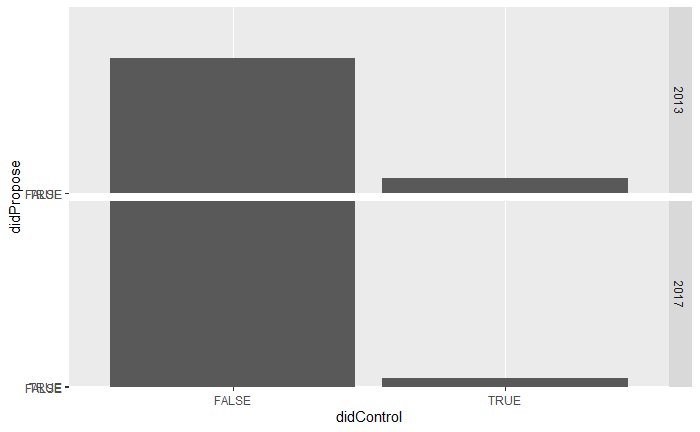

```r
ys.proposed %>% ggplot(aes(didControl,didPropose))+geom_col()+facet_grid(rows=vars(year))
```

```r
glmfit <- ys.proposed %>% glm(didPropose~didControl+year,data=.,family=binomial())
summary(glmfit)
```

```
Call:
glm(formula = didPropose ~ didControl + year, family = binomial(),
    data = .)

Deviance Residuals:
    Min       1Q   Median       3Q      Max
-2.2587   0.4031   0.4031   0.4276   0.4276

Coefficients:
                 Estimate Std. Error z value Pr(>|z|)
(Intercept)     -59.84002  167.22564  -0.358    0.720
didControlTRUE   16.17530 1102.21883   0.015    0.988
year              0.03089    0.08298   0.372    0.710

(Dispersion parameter for binomial family taken to be 1)

    Null deviance: 282.52  on 522  degrees of freedom
Residual deviance: 276.60  on 520  degrees of freedom
AIC: 282.6

Number of Fisher Scoring iterations: 17
```

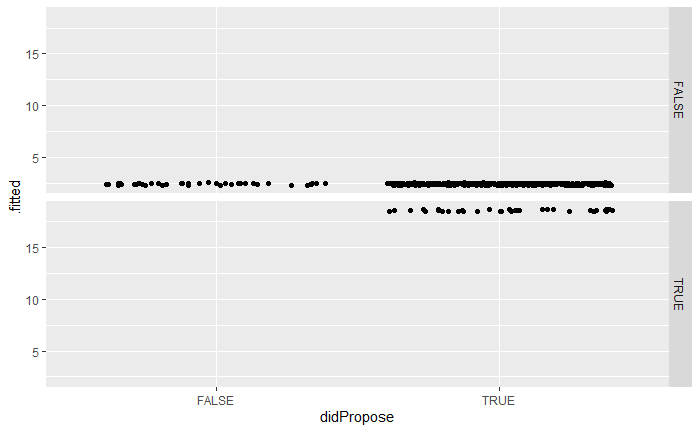

```r
augment(glmfit) %>% ggplot(aes(didPropose,.fitted))+geom_jitter()+facet_grid(rows=vars(didControl))
```